# High Performance Computing 2024 - Part 1

The requirements for this exercise are described [here](https://github.com/Foundations-of-HPC/High-Performance-Computing-2023/blob/main/ASSIGNMENTS/exercise1/exercise1.md).  
In summary, the assignment consists of the evaluation and comparison of different algorithms to perform collective communication operations among the nodes of a HPC infrastructure. The experiments are carried out on [ORFEO](https://orfeo-doc.areasciencepark.it/HPC/computational-resources/) using the [OSU benchmarks](https://mvapich.cse.ohio-state.edu/benchmarks/) for MPI operations.

The project was developed using the following software stack:  
- OpenMPI/4.1.6 with the GNU compiler,  
- Python 3.10.12 for scripting and data analysis.

Here is a summary of the contents of this report.  
• **Section 1** specifies which operations and algorithms have been considered and describes their functioning from a theoretical point of view.  
• **Section 2** is about the benchmark functions and their parameters.  
• **Section 3** evaluates the choice of the mapping strategy.  
• **Section 4** presents the results and compares the different algorithms’ performances.

## Section 1

The OSU benchmarks include a wide range of communication operations in different programming languages.  
This assignment focuses on blocking collective MPI benchmarks in C, specifically covering `MPI_Bcast` and `MPI_Reduce`.

In the broadcast operation, a process called *root* sends a message with the same data to all processes in the communicator.  
Different communication topologies can be selected, each implemented by a specific algorithm. The list of algorithms implemented in the OSU benchmarks can be retrieved with: `$ompi_info --param coll tuned --level 5 | grep "Which bcast algorithm is used"`.

If the user does not explicitly select an algorithm (or selects `0: "ignore"`), the choice of the algorithm defaults to the MPI library’s internal optimization.  
This experiment will use the default algorithm as a baseline to evaluate the performance of other algorithms:  
• `chain`: processes are arranged in a chain, with each process receiving the whole data at once from the previous process and forwarding it to the next; the root process sends the data to all other processes one by one, amounting to a *flat-tree* communication graph;  
• `pipeline`: employs the same topology as the chain algorithm, but the data is split into segments that are passed along, allowing each intermediate process to forward the previous segment while receiving a new one;  
• `binary tree`: the root sends data to two children, each of which sends data to two more and so on, doubling the number of processes reached at each step.

The reduce operation combines data from all processes into a single result at a designated root process. The algorithms for reduction use the same topologies but with distinct mechanisms:  
• `linear`: non-root processes send their data directly to the root, which applies the reduction operation as each message is received (*flat-tree* communication graph);  
• `pipeline`: Data is split into chunks, with each chunk reduced by the sender before being forwarded to the next process, allowing overlap between communication and computation;  
• `binary`: Each process collects data from its children, performs the reduction, and sends the result to its parent, utilizing a tree structure.

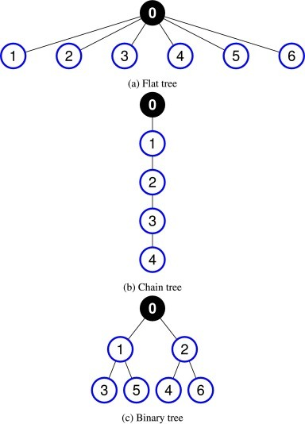

Topologies of the chosen algorithms.

## Section 2

Conveniently, the OSU benchmark functions allow the setting of some parameters by the users.  
They can be retrieved through `$mpirun osu_{operation} --help`:

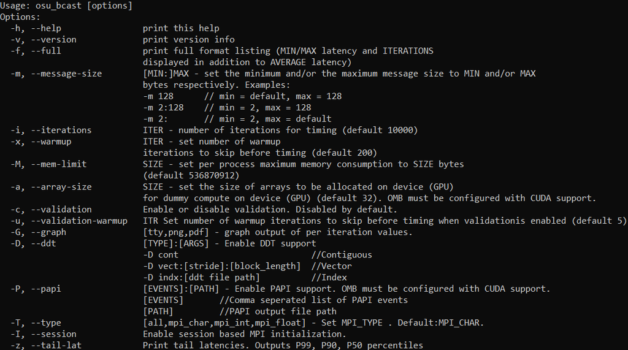

Options list for the broadcast operation.

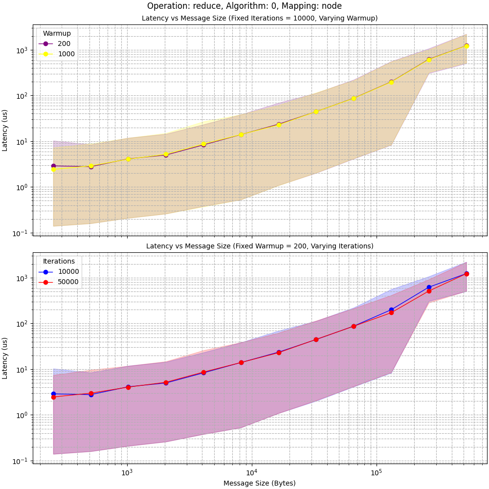

The data and plots for all the tests are available [here](https://github.com/LucaB97/hpc_project/tree/main/1/parameters_study/iterations/results).  
The results show that, at least for the selected settings, increasing the number of iterations for timing and the number of warmup iterations does not yield consistent variations in the results. Thus, from this point on, any further experiment will use the parameters with their default values.

## Section 3

The way the processes are mapped to the computational resources is a crucial factor for the performance of the algorithms.  
As pointed out in the [OpenMPI documentation](https://docs.open-mpi.org/en/v5.0.x/man-openmpi/man1/mpirun.1.html), `mpirun` automatically binds processes to `core` if the number of processes is `<=2` and to `package` otherwise, or to `none` when the binding pattern is oversubscribed.

In this section, some experiments are presented where the mapping strategy is explicitly defined for each execution. The goal is to determine if the mapping affects the communication latencies in a significant way.

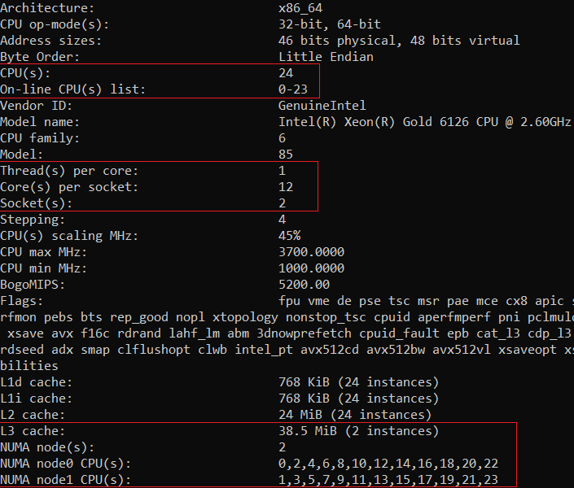

Architecture of a `thin` node, like the ones used for the experiments.

For this specific architecture, mapping by L3cache, by socket and by NUMA coincide, since each node has exactly 2 sockets, 2 NUMA regions and 2 L3caches.

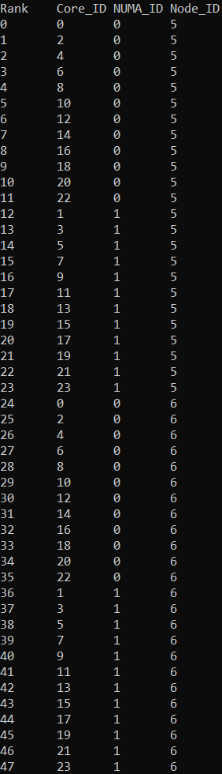

(a) core

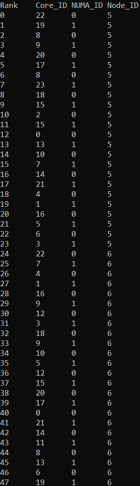

(b) L3cache

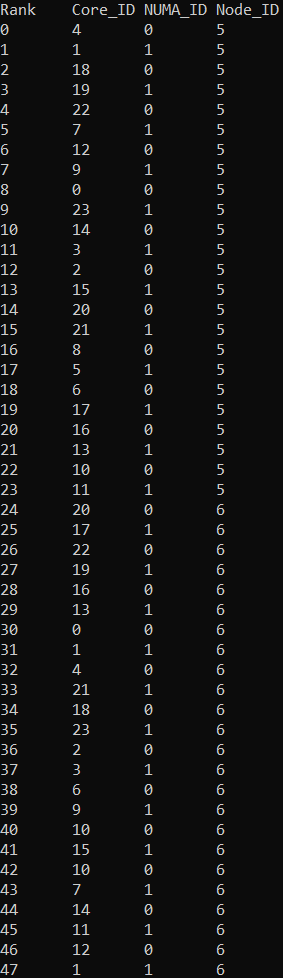

(c) NUMA

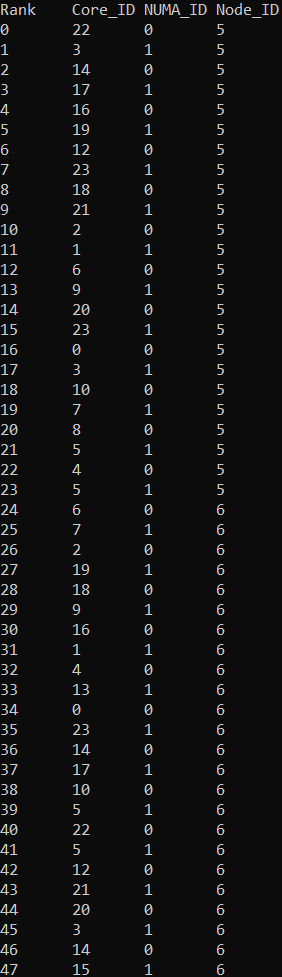

(d) socket

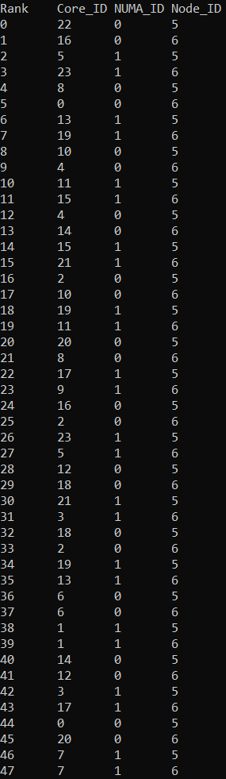

(e) node

Mapping ranks to processes:  
• `core` mapping: all the CPUs in a NUMA region are filled before moving to the next NUMA, then to the next node;  
• `L3cache`, `socket`, and `NUMA` mappings: alternatively assign processes to different regions of a node, before repeating the procedure on the next node;  
• `node` mapping: maps one process to each node and starts over until all the processes have been assigned.

As mentioned in [this](https://www.sciencedirect.com/science/article/pii/S0743731522000697?via%3Dihub) paper, at each step the time of communication is dominated by the longest communication.  
For intra-node communications, it is reasonable to imagine that communications between CPUs in different NUMA regions take longer than those in the same region.

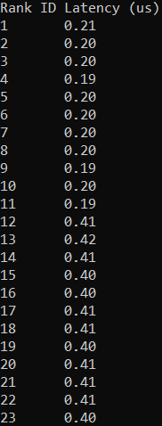

(a) 2bytes

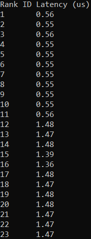

(b) 16384 bytes

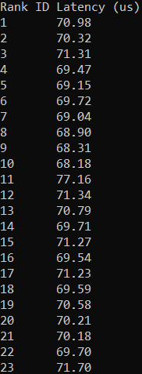

(c) 1048576 bytes

Point-to-point communication latency with different message sizes.  
The messages are communicated by the root process (`rank=0`).

Actually, when messages are smaller, the latency introduced by NUMA can be more pronounced because the data transfer itself is relatively quick. However, for larger messages, the cost of moving the data dominates the initial latency overhead introduced by NUMA locality, and there might be additional communication overhead (e.g., message segmentation, buffer management), making the NUMA effects are less visible.  
Anyway, inter-node communication is likely to have the longest latency, since the transmission of a message between nodes requires the use of a network channel.

Based on these considerations, and considering that different algorithms for a collective operation create different topologies, it is reasonable to assume that the mapping strategy might affect the total communication time for a certain algorithm by impacting the needed point-to-point communications among CPUs and their ordering.

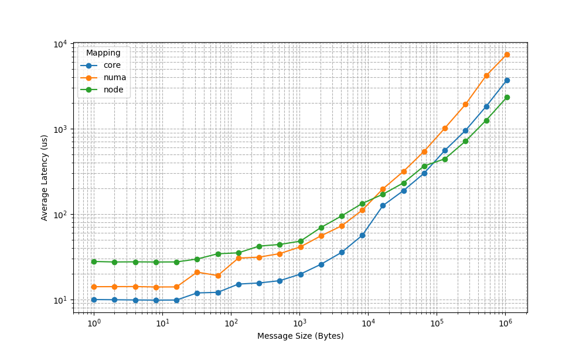

(b) Pipeline

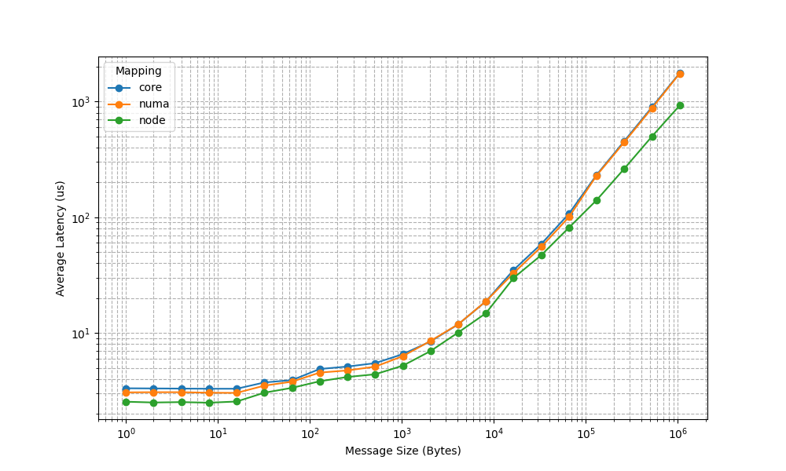

(c) Binary tree

When employing the `pipeline` algorithm, mapping by node increases the number of transmissions through the network channels, and for small messages this penalizes the overall performance. However, for bigger messages, the other mappings become less efficient because of resource contention.  
For `binary tree` algorithm, the node mapping outperforms the others for any message size. The number of inter-node communications is the same for all the mapping strategies, but when mapping by node communication between nodes happens earlier in the broadcast process. The different results might be due to internal communication delays in each node due to resource contention among the processes, for the mappings where the inter-node communications occur just on the bottom of the tree.

Similar observations hold also in the case of the reduce operation. All the data and the plots can be found [here](https://github.com/LucaB97/hpc_project/tree/main/1/mappings/mappings_vs_performance/results).

## Section 4

Here, the results of the experiments are reported.

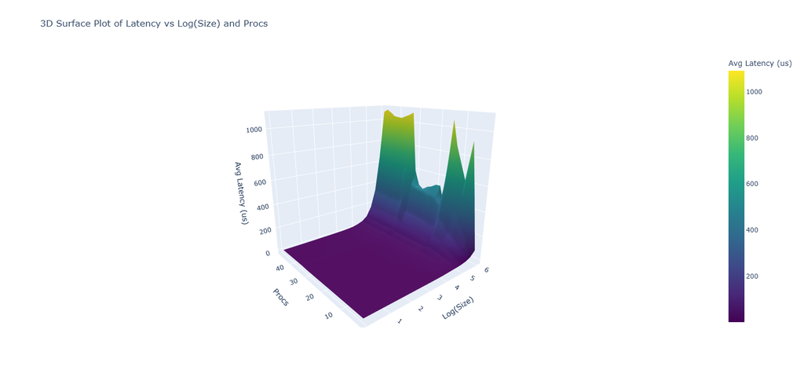

(a) Baseline

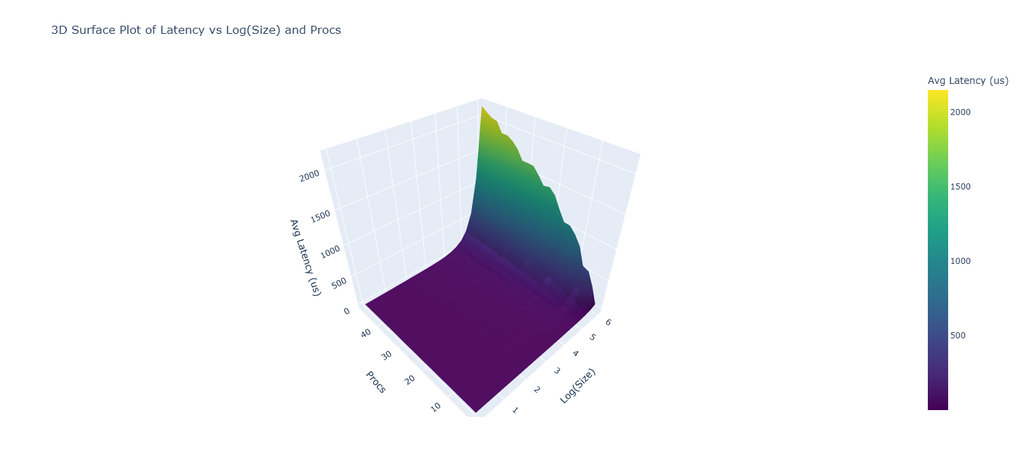

(b) Chain

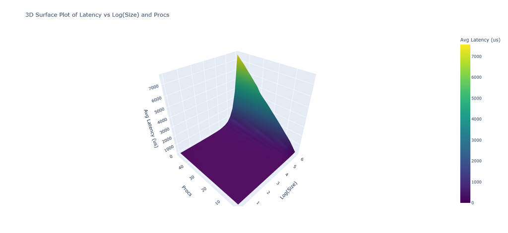

(c) Pipeline

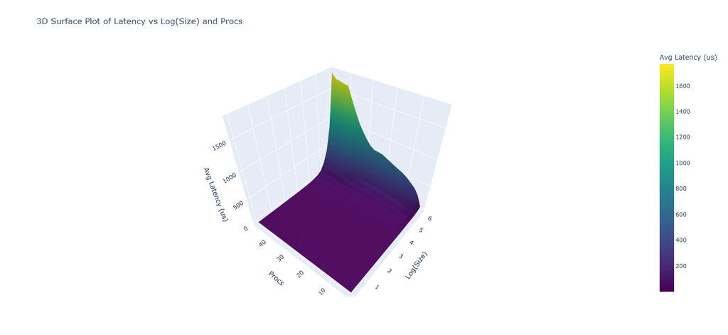

(c) Binary tree

Broadcast algorithms.

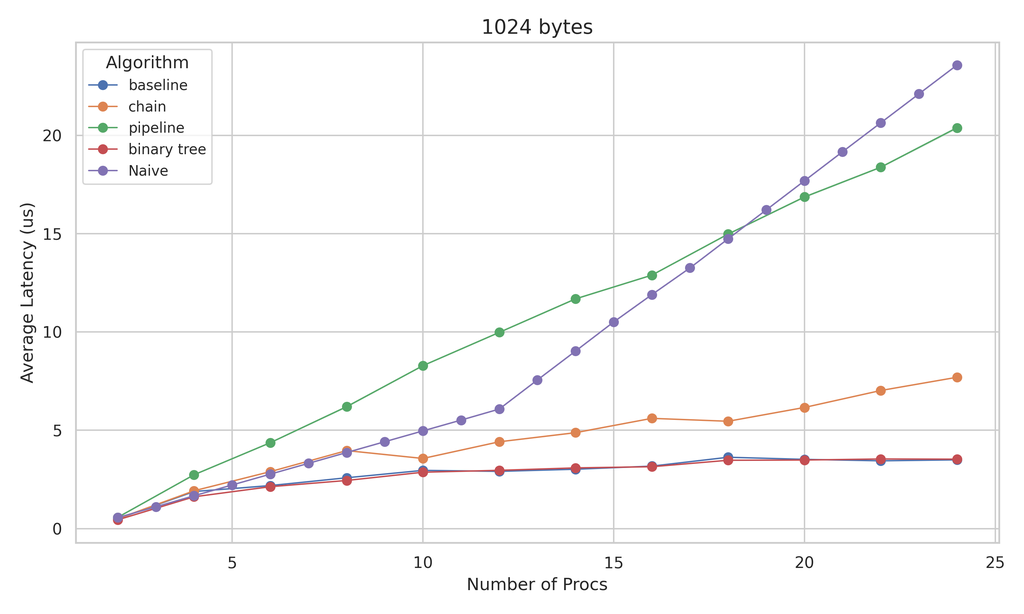

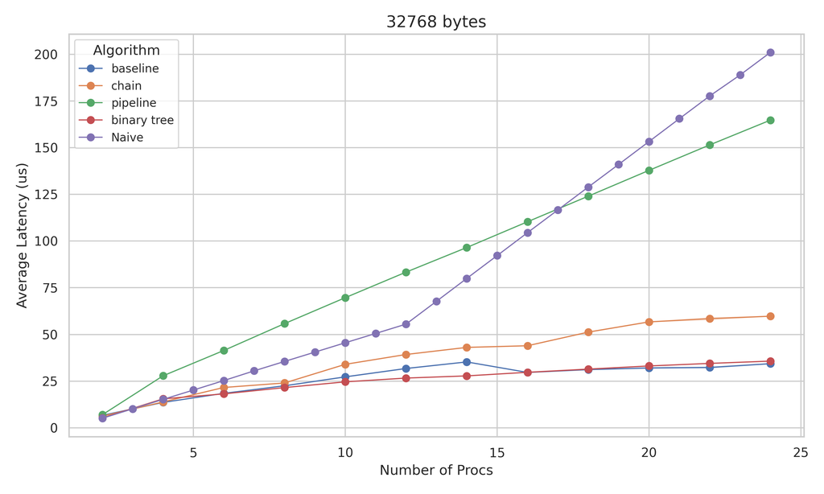

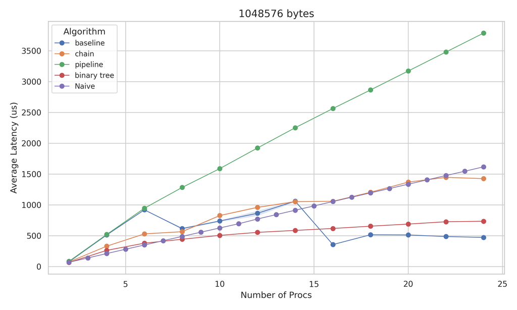

Performance model for broadcast algorithms.

Unfortunately, the data for the reduce operation is incomplete.  
However, these partial results show very similar performance for the baseline and the basic linear algorithm, with the binary tree algorithm performing much better especially for big problem sizes.

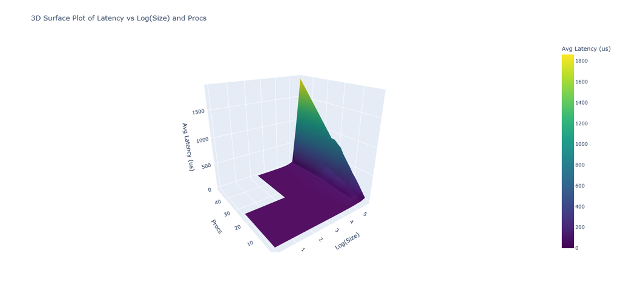

(a) Baseline

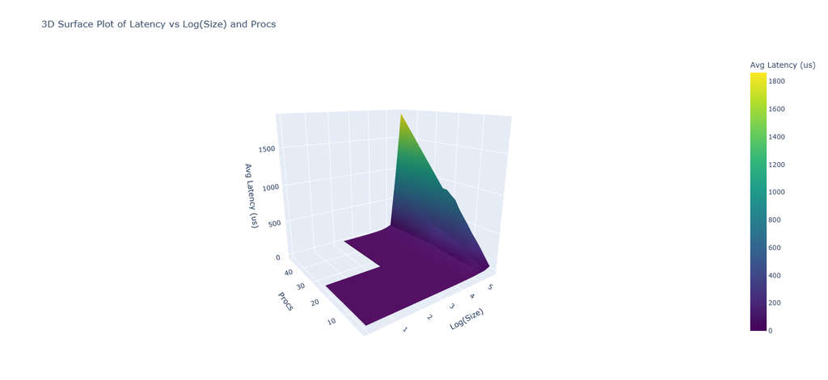

(b) Basic linear

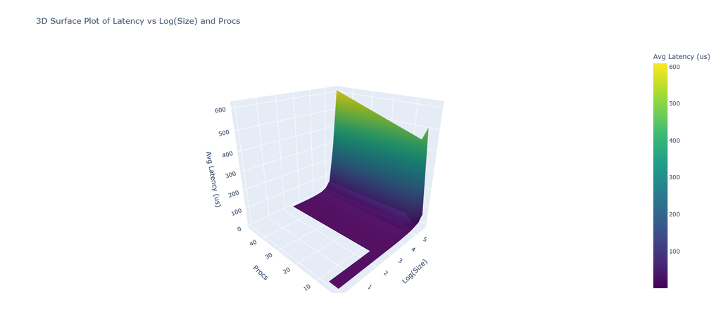

(c) Binary tree

Reduce algorithms (missing data for processes where the 3D plots are blank on the ground grid).